# PROJECT - (06th Nov, 2020 - 22nd Nov, 2020)

## PROJECT - (06th Nov, 2020 - 22nd Nov, 2020)

```python
import pandas as pd         # To read the data set
import numpy as np          # Importing numpy library
import seaborn as sns       # For data visualization
import matplotlib.pyplot as plt      # Necessary library for plotting graphs
from matplotlib import pyplot        # Importing pyplot library from matplotlib
%matplotlib inline
sns.set(color_codes = True)

from scipy.cluster.hierarchy import dendrogram, cophenet, linkage
from sklearn.cluster import KMeans              # For KMeans cluster model building
from scipy.spatial.distance import cdist        # Importing cdist functionality for elbow graph
from scipy.spatial.distance import pdist        # Importing pdist functionality for dendrograms
from sklearn.cluster import AgglomerativeClustering             # For Agg Clust model building
from mpl_toolkits.mplot3d import Axes3D         # Importing graph library for 3D visualization
from sklearn.decomposition import PCA           # Importing to run pca analysis on data
from sklearn.model_selection import KFold, cross_val_score      # Importing kfold for cross validation
from sklearn.model_selection import GridSearchCV, RandomizedSearchCV           # Importing for hypertuning model
from scipy.stats import zscore         # Import zscore library
from sklearn.preprocessing import StandardScaler           # Importing to standardize the data
from sklearn.impute import SimpleImputer              # Importing to fill in zero values in the data
from sklearn.preprocessing import LabelEncoder        # Importing label encoder

from sklearn.preprocessing import PolynomialFeatures       # Importing polynomial features library
from sklearn.pipeline import Pipeline           # Importing pipelines library
from sklearn import metrics            # Importing metrics
from sklearn.model_selection import train_test_split       # Splitting data into train and test set
from sklearn.metrics import classification_report, accuracy_score, recall_score, f1_score, roc_auc_score, average_precision_score, confusion_matrix
from sklearn.utils import resample     # Importing for data resampling
from sklearn.preprocessing import PolynomialFeatures       # Importing polynomial features
from sklearn.linear_model import LinearRegression     # For linear reg model building
from sklearn.tree import DecisionTreeRegressor        # For decision tree reg model building
from sklearn.svm import SVR            # For SVM model building
from sklearn.neighbors import KNeighborsRegressor     # For knn reg model building
from sklearn.ensemble import RandomForestRegressor    # For random forest reg model building
from sklearn.ensemble import GradientBoostingRegressor     # For gradient boost model building
from sklearn.linear_model import Ridge           # For ride model building
from sklearn.linear_model import Lasso           # For Lasso model building
```

### 1. Deliverable -1 (Exploratory data quality report reflecting the following)

### A. Univariate Analysis

```python
# Running steps to check and prepare the data

df = pd.read_csv('download-3.csv')
```

```python
df.head()
```

|  | cement | slag | ash | water | superplastic | coarseagg | fineagg | age | strength |
| --- | --- | --- | --- | --- | --- | --- | --- | --- | --- |
| 0 | 141.3 | 212.0 | 0.0 | 203.5 | 0.0 | 971.8 | 748.5 | 28 | 29.89 |
| 1 | 168.9 | 42.2 | 124.3 | 158.3 | 10.8 | 1080.8 | 796.2 | 14 | 23.51 |
| 2 | 250.0 | 0.0 | 95.7 | 187.4 | 5.5 | 956.9 | 861.2 | 28 | 29.22 |
| 3 | 266.0 | 114.0 | 0.0 | 228.0 | 0.0 | 932.0 | 670.0 | 28 | 45.85 |
| 4 | 154.8 | 183.4 | 0.0 | 193.3 | 9.1 | 1047.4 | 696.7 | 28 | 18.29 |

```python
df.tail()
```

|  | cement | slag | ash | water | superplastic | coarseagg | fineagg | age | strength |
| --- | --- | --- | --- | --- | --- | --- | --- | --- | --- |
| 1025 | 135.0 | 0.0 | 166.0 | 180.0 | 10.0 | 961.0 | 805.0 | 28 | 13.29 |
| 1026 | 531.3 | 0.0 | 0.0 | 141.8 | 28.2 | 852.1 | 893.7 | 3 | 41.30 |
| 1027 | 276.4 | 116.0 | 90.3 | 179.6 | 8.9 | 870.1 | 768.3 | 28 | 44.28 |
| 1028 | 342.0 | 38.0 | 0.0 | 228.0 | 0.0 | 932.0 | 670.0 | 270 | 55.06 |
| 1029 | 540.0 | 0.0 | 0.0 | 173.0 | 0.0 | 1125.0 | 613.0 | 7 | 52.61 |

Features(attributes) Understanding from the above dataframe :-

1.Cement measured in kg in a m3 mixture

2.Blast measured in kg in a m3 mixture

3.Fly ash measured in kg in a m3 mixture

4.Water measured in kg in a m3 mixture

5.Superplasticizer measured in kg in a m3 mixture

6.Coarse Aggregate measured in kg in a m3 mixture

7.Fine Aggregate measured in kg in a m3 mixture

8.Age day (1~365)

9.Concrete compressive strength:- measured in MPa

```python
df.shape
```

```
(1030, 9)
```

Shape of the dataframe is (1030, 9). There are 1030 rows and 9 columns in the dataset.

```python
df.size
```

```
9270
```

```python
df.isnull().sum()
```

```
cement          0
slag            0
ash             0
water           0
superplastic    0
coarseagg       0
fineagg         0
age             0
strength        0
dtype: int64
```

```python
df.count()
```

```
cement          1030
slag            1030
ash             1030
water           1030
superplastic    1030
coarseagg       1030
fineagg         1030
age             1030
strength        1030
dtype: int64
```

```python
df.dtypes
```

```
cement          float64
slag            float64
ash             float64
water           float64
superplastic    float64
coarseagg       float64
fineagg         float64
age               int64
strength        float64
dtype: object
```

```python
df.info()
```

```
<class 'pandas.core.frame.DataFrame'>
RangeIndex: 1030 entries, 0 to 1029
Data columns (total 9 columns):
 #   Column        Non-Null Count  Dtype
---  ------        --------------  -----
 0   cement        1030 non-null   float64
 1   slag          1030 non-null   float64
 2   ash           1030 non-null   float64
 3   water         1030 non-null   float64
 4   superplastic  1030 non-null   float64
 5   coarseagg     1030 non-null   float64
 6   fineagg       1030 non-null   float64
 7   age           1030 non-null   int64
 8   strength      1030 non-null   float64
dtypes: float64(8), int64(1)
memory usage: 72.5 KB
```

From the above analysis we can observe that there are no missing values present in the dataset.

```python
df.median()
```

```
cement          272.900
slag             22.000
ash               0.000
water           185.000
superplastic      6.400
coarseagg       968.000
fineagg         779.500
age              28.000
strength         34.445
dtype: float64
```

```python
df.mean()
```

```
cement          281.167864
slag             73.895825
ash              54.188350
water           181.567282
superplastic      6.204660
coarseagg       972.918932
fineagg         773.580485
age              45.662136
strength         35.817961
dtype: float64
```

```python
df.describe().transpose()
```

|  | count | mean | std | min | 25% | 50% | 75% | max |
| --- | --- | --- | --- | --- | --- | --- | --- | --- |
| cement | 1030.0 | 281.167864 | 104.506364 | 102.00 | 192.375 | 272.900 | 350.000 | 540.0 |
| slag | 1030.0 | 73.895825 | 86.279342 | 0.00 | 0.000 | 22.000 | 142.950 | 359.4 |
| ash | 1030.0 | 54.188350 | 63.997004 | 0.00 | 0.000 | 0.000 | 118.300 | 200.1 |
| water | 1030.0 | 181.567282 | 21.354219 | 121.80 | 164.900 | 185.000 | 192.000 | 247.0 |
| superplastic | 1030.0 | 6.204660 | 5.973841 | 0.00 | 0.000 | 6.400 | 10.200 | 32.2 |
| coarseagg | 1030.0 | 972.918932 | 77.753954 | 801.00 | 932.000 | 968.000 | 1029.400 | 1145.0 |
| fineagg | 1030.0 | 773.580485 | 80.175980 | 594.00 | 730.950 | 779.500 | 824.000 | 992.6 |
| age | 1030.0 | 45.662136 | 63.169912 | 1.00 | 7.000 | 28.000 | 56.000 | 365.0 |
| strength | 1030.0 | 35.817961 | 16.705742 | 2.33 | 23.710 | 34.445 | 46.135 | 82.6 |

Obervation :

From above we can see that Mean & Median are nearly same for ( Cement, Water, Superplastic, Coarseagg, Fineagg, Strength ), so we can say it is approximately normally distributed. On the other hand ( Slag, Ash, Age ) have values at the maximum portion so we can say it is skewed towards right side.

```python
df.skew()
```

```
cement          0.509481
slag            0.800717
ash             0.537354
water           0.074628
superplastic    0.907203
coarseagg      -0.040220
fineagg        -0.253010
age             3.269177
strength        0.416977
dtype: float64
```

```python
df.std()
```

```
cement          104.506364
slag             86.279342
ash              63.997004
water            21.354219
superplastic      5.973841
coarseagg        77.753954
fineagg          80.175980
age              63.169912
strength         16.705742
dtype: float64
```

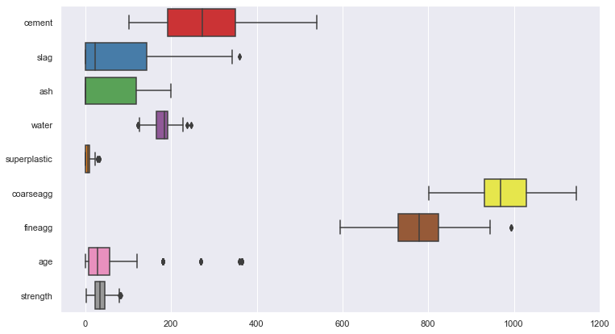

```python
plt.figure(figsize=(12,7))
sns.boxplot(data = df, orient = 'h', palette = 'Set1', dodge = False);
```

Observation:

From the above boxplot we can see that there are outliers in some columns ( Slag, Water, Superplastic, Fineagg, Age ). I will be finding the outliers counts in individual attributes analysis and fixing the outliers after visualization and analysis of each attribute.

### Analysis of each attribute with the help of plots

### 1. Cement

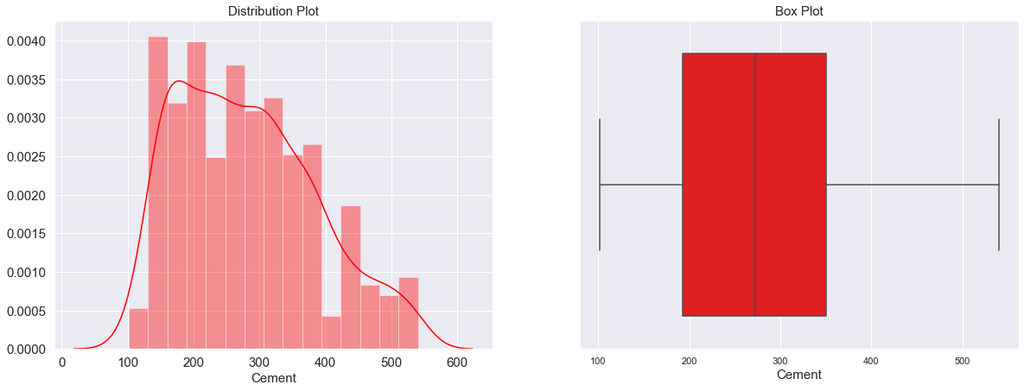

```python
# Plotting a visual analysis of cement column

fig,(ax1, ax2) = plt.subplots(nrows = 1, ncols = 2, figsize = (13,7))
fig.set_size_inches (20,7)

sns.distplot(df['cement'], ax = ax1, color = 'red')
ax1.tick_params (labelsize = 15)
ax1.set_title('Distribution Plot', fontsize = 15)
ax1.set_xlabel('Cement', fontsize = 15)

sns.boxplot(df['cement'], ax = ax2, color = 'red')
ax2.set_title('Box Plot', fontsize = 15)
ax2.set_xlabel('Cement', fontsize = 15);
```

Observation:

From the above analysis we can see that there are no outliers in "Cement Column" & it looks like it is almost normally distributed. Cement values lies in between the range 100 to 500.

### 2. Blast

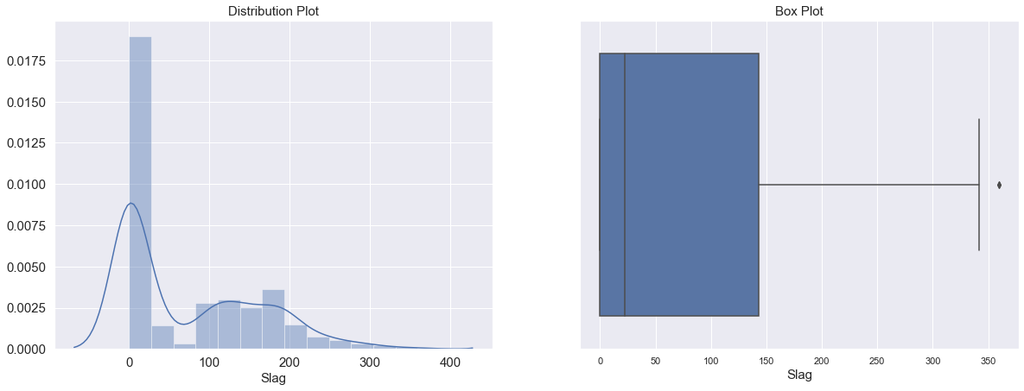

```python
# Plotting a visual analysis of slag column

fig,(ax1, ax2) = plt.subplots(nrows = 1, ncols = 2, figsize = (13,7))
fig.set_size_inches (20,7)

sns.distplot(df['slag'], ax = ax1, color = 'b')
ax1.tick_params(labelsize = 15)
ax1.set_title('Distribution Plot', fontsize = 15)
ax1.set_xlabel('Slag', fontsize = 15)

sns.boxplot(df['slag'], ax = ax2, color = 'b')
ax2.set_title('Box Plot', fontsize = 15)
ax2.set_xlabel('Slag', fontsize = 15);
```

Observation:

```python
# Checking outliers in slag


outlier_cols1 = []

Q1 = df['slag'].quantile (0.25)   # 1st Quartile
Q3 = df['slag'].quantile (0.75)   # 3rd Quartile

IQR = Q3 - Q1         # Interquartile range

LTV_slag = Q1 - 1.5 * IQR         # Lower range bound
UTV_slag = Q3 + 1.5 * IQR         # Upper range bound

print('Interqaurtile range =', IQR)
print('Slag <', LTV_slag, 'and >', LTV_slag, 'are outliers')
print('Number of outliers in the slag column below the lower whisker =', df[df['slag'] < (Q1 - (1.5*IQR))]['slag'].count())
print('Number of outliers in the slag column above the upper whisker =', df[df['slag'] > (Q3 + (1.5*IQR))]['slag'].count())

outlier_cols1.append('slag')
upperLowerBound_Disct = {'slag' : UTV_slag}
```

```
Interqaurtile range = 142.95
Slag < -214.42499999999998 and > -214.42499999999998 are outliers
Number of outliers in the slag column below the lower whisker = 0
Number of outliers in the slag column above the upper whisker = 2
```

Observation :

We can observe from the outlier analysis above that we have a total of 2 outliers in "Slag Column" which is towards the upper whisker. We will treat them later on.

### 3. Fly Ash

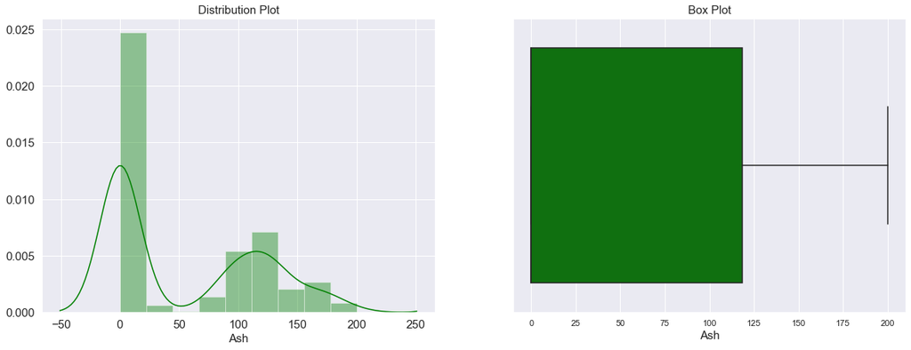

```python
# Plotting a visual analysis of ash column

fig,(ax1, ax2) = plt.subplots(nrows = 1, ncols = 2, figsize = (13,7))
fig.set_size_inches(20,7)

sns.distplot(df['ash'], ax = ax1, color = 'green')
ax1.tick_params (labelsize= 15)
ax1.set_title('Distribution Plot', fontsize = 15)
ax1.set_xlabel('Ash', fontsize = 15)

sns.boxplot(df['ash'], ax = ax2, color = 'green')
ax2.set_title('Box Plot', fontsize = 15)
ax2.set_xlabel('Ash', fontsize = 15);
```

Observation:

From the above analysis we can see that outliers are not present in "Ash Column" with the distribution having a rightward skewness. Slag values lie in between the range 100 to 200, but we also notice a tall tower between 0 to 20.

### 4. Water

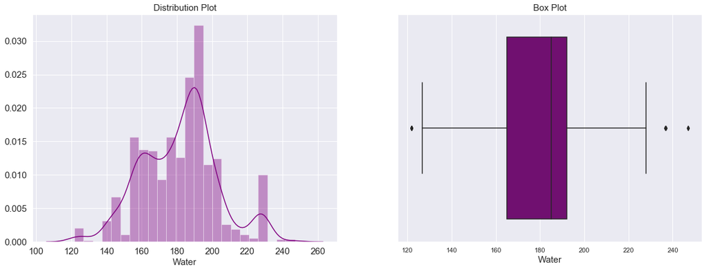

```python
# Plotting a visual analysis of water column

fig, (ax1, ax2) = plt.subplots(nrows = 1, ncols = 2, figsize = (13,7))
fig.set_size_inches (20,7)

sns.distplot(df['water'], ax = ax1, color = 'purple')
ax1.tick_params(labelsize = 15)
ax1.set_title('Distribution Plot', fontsize = 15)
ax1.set_xlabel('Water', fontsize = 15)

sns.boxplot(df['water'], ax = ax2, color = 'purple')
ax2.set_title('Box Plot', fontsize = 15)
ax2.set_xlabel('Water', fontsize = 15);
```

Observation:

```python
# Checking outliers in water

outlier_cols2 = []

Q1 = df['water'].quantile(0.25)   # 1st Quartile
Q3 = df['water'].quantile(0.75)   # 3rd Quartile

IQR = Q3 - Q1      # Interquartile range

LTV_water = Q1 - 1.5 * IQR        # Lower range bound
UTV_water = Q3 + 1.5 * IQR        # Upper range bound

print('Interquartile range = ', IQR)
print('Water <', LTV_water, 'and >', UTV_water, 'are outliers')
print('Number of outliers in the water column below the lower whisker =', df[df['water'] < (Q1 - (1.5*IQR))]['water'].count())
print('Number of outliers in the water columns above the upper whisker =', df[df['water'] > (Q3 + (1.5*IQR))]['water'].count())

outlier_cols2.append('water')
upperLowerBound_Disct = {'water' : UTV_water}
```

```
Interquartile range =  27.099999999999994
Water < 124.25000000000001 and > 232.64999999999998 are outliers
Number of outliers in the water column below the lower whisker = 5
Number of outliers in the water columns above the upper whisker = 4
```

Observation :

We can observe from the outlier analysis above that we have a total of 9 outliers in "Water Column". 5 towards the lower whisker and 4 towards the upper whisker. We will treat them later on.

### 4. Superplasticizer

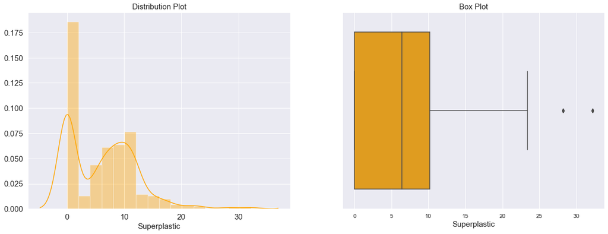

```python
# Plotting a visual analysis of superplastic column

fig, (ax1, ax2) = plt.subplots(nrows = 1, ncols = 2, figsize = (13,7))
fig.set_size_inches (20,7)

sns.distplot(df['superplastic'], ax = ax1, color = 'orange')
ax1.tick_params(labelsize = 15)
ax1.set_title('Distribution Plot', fontsize = 15)
ax1.set_xlabel('Superplastic', fontsize = 15)

sns.boxplot(df['superplastic'], ax = ax2, color = 'orange')
ax2.set_title('Box Plot', fontsize = 15)
ax2.set_xlabel('Superplastic', fontsize = 15);
```

Observation:

From the above analysis we can see that outliers are present in "Superplastic Column" with the distribution having a rightward skewness. Superplastic values range from 0 to 20.

```python
# Checking outliers in superplastic

outlier_cols3 = []

Q1 = df['superplastic'].quantile(0.25)   # 1st Quartile
Q3 = df['superplastic'].quantile(0.75)   # 3rd Quartile

IQR = Q3 - Q1        # Interquartile range

LTV_superplastic = Q1 - 1.5 * IQR        # Lower range bound
UTV_superplastic = Q3 + 1.5 * IQR        # Upper range bound

print('Interquartile range =', IQR)
print('Superplastic <', LTV_superplastic, 'and >', UTV_superplastic, 'are outliers')
print('Number of outliers in the superplastic column below the lower whisker =', df[df['superplastic'] < (Q1 - (1.5*IQR))]['superplastic'].count())
print('Number of outliers in the superplastic column above the upper whisker =', df[df['superplastic'] > (Q3 + (1.5*IQR))]['superplastic'].count())

outlier_cols3.append('superplastic')
upperLowerBound_Disct = {'superplastic' : UTV_superplastic}
```

```
Interquartile range = 10.2
Superplastic < -15.299999999999999 and > 25.5 are outliers
Number of outliers in the superplastic column below the lower whisker = 0
Number of outliers in the superplastic column above the upper whisker = 10
```

Observation :

We can observe from the outlier analysis above that we have a total of 10 outliers in "Superplastic Column". All 10 towards the upper whisker. We will treat them later on.

### 5. Coarse Aggregate

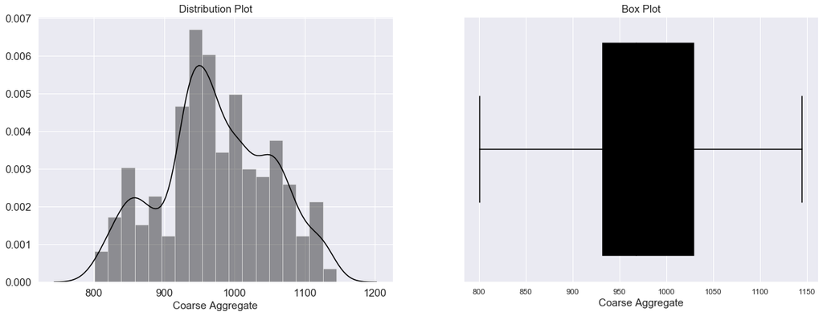

```python
# Plotting a visual analysis of coarseagg column

fig, (ax1, ax2) = plt.subplots(nrows = 1, ncols = 2, figsize = (13,7))
fig.set_size_inches (20,7)

sns.distplot(df['coarseagg'], ax = ax1, color = 'black')
ax1.tick_params(labelsize = 15)
ax1.set_title('Distribution Plot', fontsize = 15)
ax1.set_xlabel('Coarse Aggregate', fontsize = 15)

sns.boxplot(df['coarseagg'], ax = ax2, color = 'black')
ax2.set_title('Box Plot', fontsize = 15)
ax2.set_xlabel('Coarse Aggregate', fontsize = 15);
```

Observation:

### 5. Fine Aggregate

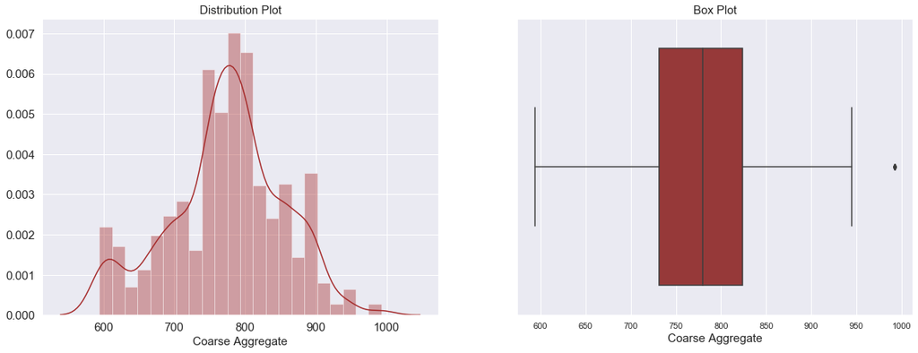

```python
# Plotting a visual analysis of fineagg column

fig, (ax1, ax2) = plt.subplots(nrows = 1, ncols = 2, figsize = (13,7))
fig.set_size_inches (20,7)

sns.distplot(df['fineagg'], ax = ax1, color = 'brown')
ax1.tick_params(labelsize = 15)
ax1.set_title('Distribution Plot', fontsize = 15)
ax1.set_xlabel('Coarse Aggregate', fontsize = 15)

sns.boxplot(df['fineagg'], ax = ax2, color = 'brown')
ax2.set_title('Box Plot', fontsize = 15)
ax2.set_xlabel('Coarse Aggregate', fontsize = 15);
```

Observation:

```python
# Checking outliers in fine aggregate

outlier_cols4 = []

Q1 = df['fineagg'].quantile(0.25)   # 1st Quartile
Q3 = df['fineagg'].quantile(0.75)   # 3rd Quartile

IQR = Q3 - Q1       # Interquartile range

LTV_fineagg = Q1 - 1.5 * IQR        # Lower range bound
UTV_fineagg = Q3 + 1.5 * IQR        # Upper range bound

print('Interquartile range =', IQR)
print('Fineagg <', LTV_fineagg, 'and >', UTV_fineagg, 'are outliers')
print('Number of outliers in the fineagg column below the lower whisker =', df[df['fineagg'] < (Q1 - (1.5*IQR))]['fineagg'].count())
print('Number of outliers in the fineagg column above the upper whisker =', df[df['fineagg'] > (Q3 + (1.5*IQR))]['fineagg'].count())

outlier_cols4.append('fineagg')
upperLowerBound_Disct = {'fineagg' : UTV_fineagg}
```

```
Interquartile range = 93.05000000000007
Fineagg < 591.3749999999998 and > 963.575 are outliers
Number of outliers in the fineagg column below the lower whisker = 0
Number of outliers in the fineagg column above the upper whisker = 5
```

Observation :

We can observe from the outlier analysis above that we have a total of 5 outliers in "Fineagg Column". All 5 towards the upper whisker. We will treat them later on.

### 6. Age

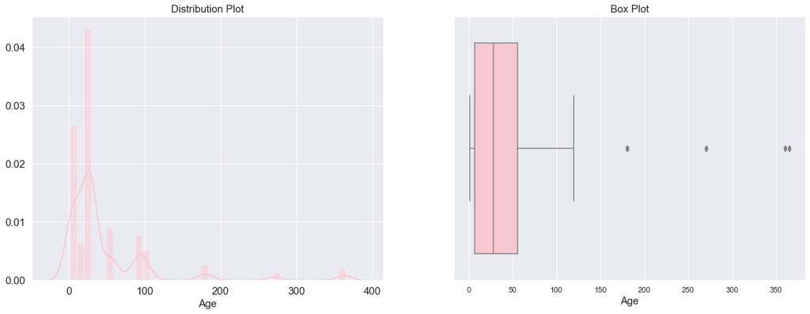

```python
# Plotting a visual analysis of age column

fig, (ax1, ax2) = plt.subplots(nrows = 1, ncols = 2, figsize = (13,7))
fig.set_size_inches (20,7)

sns.distplot(df['age'], ax = ax1, color = 'pink')
ax1.tick_params (labelsize = 15)
ax1.set_title('Distribution Plot', fontsize = 15)
ax1.set_xlabel('Age', fontsize = 15)

sns.boxplot(df['age'], ax = ax2, color = 'pink')
ax2.set_title('Box Plot', fontsize = 15)
ax2.set_xlabel('Age', fontsize = 15);
```

Observation:

From the above analysis we can see that outliers are present in "Age Column" with the distribution having a rightward skewness.

```python
# Checking outliers in age

outlier_cols5 = []

Q1 = df['age'].quantile(0.25)   # 1st Quartile
Q3 = df['age'].quantile(0.75)   # 3rd Quartile

IQR = Q3 - Q1       # Interquartile range

LTV_age = Q1 - 1.5 * IQR        # Lower range bound
UTV_age = Q3 + 1.5 * IQR        # Upper range bound

print('Interquartile range =', IQR)
print('Age <', LTV_age, 'and >', UTV_age, 'are outliers')
print('Number of outliers in the age column below the lower whisker =', df[df['age'] < (Q1 - (1.5*IQR))]['age'].count())
print('Number of outliers in the age column above the upper whisker =', df[df['age'] > (Q3 + (1.5*IQR))]['age'].count())

outlier_cols5.append('age')
upperLowerBound_Disct = {'age' : UTV_age}
```

```
Interquartile range = 49.0
Age < -66.5 and > 129.5 are outliers
Number of outliers in the age column below the lower whisker = 0
Number of outliers in the age column above the upper whisker = 59
```

Observation :

We can observe from the outlier analysis above that we have a total of 59 outliers in "Age Column". All 59 towards the upper whisker. We will treat them later on.

### 7. Strength

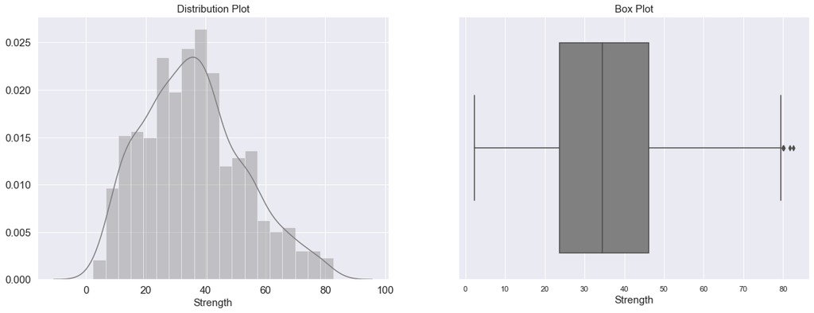

```python
# Plotting a visual analysis of strength column

fig, (ax1, ax2) = plt.subplots(nrows = 1, ncols = 2, figsize = (13,7))
fig.set_size_inches (20,7)

sns.distplot(df['strength'], ax = ax1, color = 'grey')
ax1.tick_params(labelsize = 15)
ax1.set_title('Distribution Plot', fontsize = 15)
ax1.set_xlabel('Strength', fontsize = 15)

sns.boxplot(df['strength'], ax = ax2, color = 'grey')
ax2.set_title('Box Plot', fontsize = 15)
ax2.set_xlabel('Strength', fontsize = 15);
```

Observation:

From the above analysis we can see that outliers are present in "Strength Column" with the distribution having a rightward skewness.

```python
# Checking outliers in strength

outlier_cols6 = []

Q1 = df['strength'].quantile(0.25)   # 1st Quartile
Q3 = df['strength'].quantile(0.75)   # 3rd Quartile

IQR = Q3 - Q1        # Interquartile range

LTV_strength = Q1 - 1.5 * IQR        # Lower range bound
UTV_strength = Q3 + 1.5 * IQR        # Upper range bound

print('Interquartile range =', IQR)
print('Strength <', LTV_strength, 'and >', UTV_strength, 'are outliers')
print('Number of outliers in the strength column below the lower whisker =', df[df['strength'] < (Q1 - (1.5*IQR))]['strength'].count())
print('Number of outliers in the strength column above the upper whisker =', df[df['strength'] > (Q3 + (1.5*IQR))]['strength'].count())

outlier_cols6.append ('strength')
upperLowerBound_Dist = {'strength' : UTV_strength}
```

```
Interquartile range = 22.425000000000008
Strength < -9.927500000000013 and > 79.77250000000001 are outliers
Number of outliers in the strength column below the lower whisker = 0
Number of outliers in the strength column above the upper whisker = 4
```

Observation :

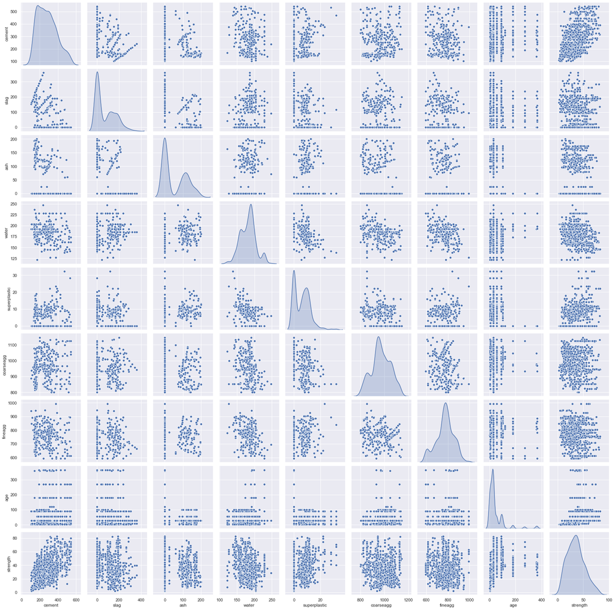

```python
# Pairplot visual analysis to check correlation amongst different fields

sns.pairplot(df, diag_kind = 'kde')
plt.show()
```

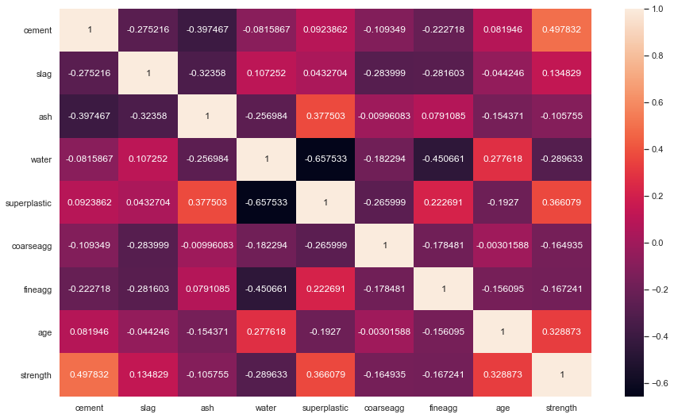

```python
df.corr()

plt.figure(figsize = (15,9))
sns.heatmap(df.corr(), annot = True, fmt = 'g');
```

Observation : From the above pair plot & heatmap we can infer the relationship amongst the attributes and target column as follows:

1. No high correlation between any two features. Ash and Cement are having corelation of (-0.40). Superplastic and Water are having corelation of (-0.66). Fineagg and Water are having corelation of (-0.45).
1. Strength have some positive linear relation with (Cement and some with Superplastic that means if the quantity of Cement or Superplastic is more then Concrete is having more Strength.
1. Also it is quite visible that there are multiple gaussians in slag, ash, water, superplastic & age.
1. Rest of the relations between other individual attributes are mostly cloud shaped or symmetrical shaped.

### C. Pick one strategy to address the presence outliers and missing values and perform necessary imputation

------------------------ Fixing Outliers ------------------------

- As we have seen above outlier are present in the given dataset.
- There are multiple ways to deal with outliers but I mostly prefer either to drop the outliers or repalce it with median/mean.
- Here I am going to replace the outliers with median because if we drop them, there may be chance to loose some important information which we dont want to as it could hamper our overall anylysis.

```python
# Showing the columns where outliers exist

print('These are the columns which have outliers : \n\n', outlier_cols1, outlier_cols2, outlier_cols3, outlier_cols4, outlier_cols5, outlier_cols6)
```

```
These are the columns which have outliers :

 ['slag'] ['water'] ['superplastic'] ['fineagg'] ['age'] ['strength']
```

```python
df_new = df.copy()
```

```python
# Treating outliers present in respective columns

for col_name in df_new.columns[:]:
    q1 = df_new[col_name].quantile(0.25)
    q3 = df_new[col_name].quantile(0.75)
    iqr = q3 - q1
    low = q1-1.5*iqr
    high = q3+1.5*iqr

    df_new.loc[(df_new[col_name] < low) | (df_new[col_name] > high), col_name] = df_new[col_name].median()
```

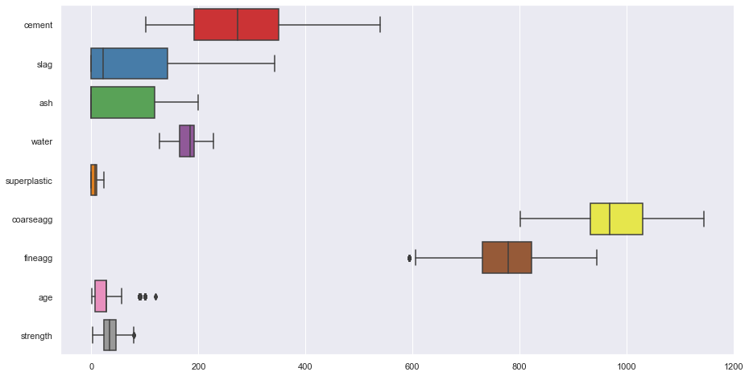

```python
plt.figure(figsize=(15,8))
sns.boxplot(data = df_new, orient='h', palette='Set1', dodge=False);
```

Observation :

Now we can see from the above visual analysis of boxplots that most of the outliers are replaced with their median. We can see that most of the outliers are removed, but because of their gaussians replacing it with median values, the attributes raised with new outliers can ignore.

```python
df_new.shape
```

```
(1030, 9)
```

```python
df_new.head()
```

|  | cement | slag | ash | water | superplastic | coarseagg | fineagg | age | strength |
| --- | --- | --- | --- | --- | --- | --- | --- | --- | --- |
| 0 | 141.3 | 212.0 | 0.0 | 203.5 | 0.0 | 971.8 | 748.5 | 28.0 | 29.89 |
| 1 | 168.9 | 42.2 | 124.3 | 158.3 | 10.8 | 1080.8 | 796.2 | 14.0 | 23.51 |
| 2 | 250.0 | 0.0 | 95.7 | 187.4 | 5.5 | 956.9 | 861.2 | 28.0 | 29.22 |
| 3 | 266.0 | 114.0 | 0.0 | 228.0 | 0.0 | 932.0 | 670.0 | 28.0 | 45.85 |
| 4 | 154.8 | 183.4 | 0.0 | 193.3 | 9.1 | 1047.4 | 696.7 | 28.0 | 18.29 |

### 2. Deliverable - 2 (Feature Engineering techniques)

### Creating Composite Features, ( "Water" & "Cement" ratio by dividing the values of "Water" with "Cement" )

```python
df_new.insert(df_new.shape[-1]-1,'water-cement-ratio', df_new['water']/df_new['cement'])
```

```python
df_new.head()
```

|  | cement | slag | ash | water | superplastic | coarseagg | fineagg | age | water-cement-ratio | strength |
| --- | --- | --- | --- | --- | --- | --- | --- | --- | --- | --- |
| 0 | 141.3 | 212.0 | 0.0 | 203.5 | 0.0 | 971.8 | 748.5 | 28.0 | 1.440198 | 29.89 |
| 1 | 168.9 | 42.2 | 124.3 | 158.3 | 10.8 | 1080.8 | 796.2 | 14.0 | 0.937241 | 23.51 |
| 2 | 250.0 | 0.0 | 95.7 | 187.4 | 5.5 | 956.9 | 861.2 | 28.0 | 0.749600 | 29.22 |
| 3 | 266.0 | 114.0 | 0.0 | 228.0 | 0.0 | 932.0 | 670.0 | 28.0 | 0.857143 | 45.85 |
| 4 | 154.8 | 183.4 | 0.0 | 193.3 | 9.1 | 1047.4 | 696.7 | 28.0 | 1.248708 | 18.29 |

```python
df_new.shape
```

```
(1030, 10)
```

### Creating (Water, Cement ratio with Slag & Ash) by dividing the values of (Water with Cement, Slag & Ash)

```python
df_new.insert(df_new.shape[-1]-1,'water-ratio_with_cement_slag_ash',df_new['water']/(df_new['cement'] + df_new['ash'] + df_new['slag']))
```

```python
df_new.head()
```

|  | cement | slag | ash | water | superplastic | coarseagg | fineagg | age | water-cement-ratio | water-ratio_with_cement_slag_ash | strength |
| --- | --- | --- | --- | --- | --- | --- | --- | --- | --- | --- | --- |
| 0 | 141.3 | 212.0 | 0.0 | 203.5 | 0.0 | 971.8 | 748.5 | 28.0 | 1.440198 | 0.575998 | 29.89 |
| 1 | 168.9 | 42.2 | 124.3 | 158.3 | 10.8 | 1080.8 | 796.2 | 14.0 | 0.937241 | 0.471974 | 23.51 |
| 2 | 250.0 | 0.0 | 95.7 | 187.4 | 5.5 | 956.9 | 861.2 | 28.0 | 0.749600 | 0.542089 | 29.22 |
| 3 | 266.0 | 114.0 | 0.0 | 228.0 | 0.0 | 932.0 | 670.0 | 28.0 | 0.857143 | 0.600000 | 45.85 |
| 4 | 154.8 | 183.4 | 0.0 | 193.3 | 9.1 | 1047.4 | 696.7 | 28.0 | 1.248708 | 0.571555 | 18.29 |

```python
df_new.shape
```

```
(1030, 11)
```

```python
df_new.isnull().sum()
```

```
cement                              0
slag                                0
ash                                 0
water                               0
superplastic                        0
coarseagg                           0
fineagg                             0
age                                 0
water-cement-ratio                  0
water-ratio_with_cement_slag_ash    0
strength                            0
dtype: int64
```

```python
df_new = df_new.apply(zscore)
df_new.head()
```

|  | cement | slag | ash | water | superplastic | coarseagg | fineagg | age | water-cement-ratio | water-ratio_with_cement_slag_ash | strength |
| --- | --- | --- | --- | --- | --- | --- | --- | --- | --- | --- | --- |
| 0 | -1.339017 | 1.625902 | -0.847144 | 1.060879 | -1.091166 | -0.014398 | -0.305676 | -0.153159 | 2.210127 | 0.834124 | -0.349209 |
| 1 | -1.074790 | -0.363717 | 1.096078 | -1.134020 | 0.881615 | 1.388141 | 0.300692 | -0.656933 | 0.602220 | 0.013241 | -0.736906 |
| 2 | -0.298384 | -0.858192 | 0.648965 | 0.279067 | -0.086509 | -0.206121 | 1.126981 | -0.153159 | 0.002350 | 0.566537 | -0.389923 |
| 3 | -0.145209 | 0.477594 | -0.847144 | 2.250592 | -1.091166 | -0.526517 | -1.303578 | -0.153159 | 0.346154 | 1.023533 | 0.620640 |
| 4 | -1.209776 | 1.290784 | -0.847144 | 0.565570 | 0.571085 | 0.958372 | -0.964165 | -0.153159 | 1.597951 | 0.799068 | -1.054112 |

### Splitting X-independent attributes and Y-dependent attributes and keeping the test set seperate

```python
x = df_new.drop(['strength'], axis = 1)
y = df_new[['strength']]
```

```python
xtrain_val, x_test, ytrain_val, y_test = train_test_split(x,y, random_state = 1, test_size = 0.20)
```

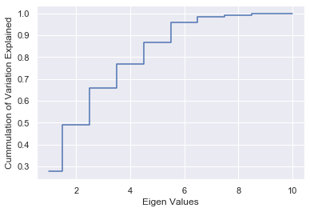

```python
pca_model = PCA(n_components = 10)
pca_model.fit(x)
plt.step(list(range(1,11)), np.cumsum(pca_model.explained_variance_ratio_),where = 'mid')
plt.ylabel('Cummulation of Variation Explained')
plt.xlabel('Eigen Values')
plt.show()
```

```python
clusters=range(1,11)
mean_distortions=[]
for val in clusters:
    kmeans = KMeans(n_clusters = val)
    kmeans.fit(df_new)
    mean_distortions.append(sum(np.min(cdist(df_new,kmeans.cluster_centers_),axis=1))/df_new.shape[0])
```

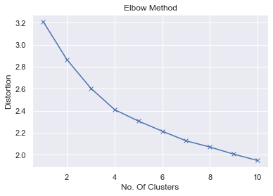

```python
plt.plot(clusters, mean_distortions,'bx-')
plt.xlabel('No. Of Clusters')
plt.ylabel('Distortion')
plt.title('Elbow Method')
```

Dimensionality Reduction :

Now 6 dimensions seems good. With 6 variables we can explain over 95% of the variation in the original data.

```python
pca_df = PCA(n_components= 6)
pca_df.fit(x)       # Fitting the data
pca_df=pca_df.transform(x)      # Transforming the data
PCA_data=pd.DataFrame(pca_df)   #Creatinf PCA_dataframe
PCA_data.head()
```

|  | 0 | 1 | 2 | 3 | 4 | 5 |
| --- | --- | --- | --- | --- | --- | --- |
| 0 | 3.083386 | 0.040001 | 1.652794 | 0.068281 | -0.003846 | -0.826556 |
| 1 | -0.047097 | -1.989499 | -0.729584 | -1.193189 | -0.949700 | -0.716174 |
| 2 | 0.433655 | -0.742816 | -1.057868 | 0.709230 | -0.214827 | 0.644029 |
| 3 | 2.161864 | 1.938736 | 0.910421 | -0.045822 | 0.133737 | 0.887062 |
| 4 | 1.911802 | -0.266415 | 1.300126 | -1.006466 | -0.117337 | -1.192265 |

### Splitting the data with K-Fold Cross Validation, 10 folds, Training and Validation set

```python
kf = KFold(n_splits = 10, random_state = 1, shuffle = True)
kf.get_n_splits(xtrain_val)
print(kf)

for train_index, val_index in kf.split(xtrain_val):
    print('Train :', train_index, 'Validation :', val_index)
    x_train, x_val = xtrain_val.iloc[train_index], xtrain_val.iloc[val_index]
    y_train, y_val = ytrain_val.iloc[train_index], ytrain_val.iloc[val_index]
```

[output not shown]

[output cut: 446 more lines]

### 3. Deliverable - 3 (create the model )

### A. Support Vector Regressor

### Creating a Pipeline to scale and then fit the model

```python
pipe_svr = Pipeline([('scl', StandardScaler()), ('svr', SVR())]) # Pipeline building
param_grid = {'svr__C': [0.01, 0.1, 1], 'svr__gamma': [0.1, 1],'svr__kernel':['rbf','poly']}    # Parameter grid
grid_svr = GridSearchCV(pipe_svr , param_grid = param_grid, cv = 5)

grid_svr.fit(x_train, y_train.values.ravel())       # Fitting the data in the model

print(" Best cross-validation score obtained is: {:.2f}". format( grid_svr.best_score_))
print(" Best parameters as part of Gridsearch is: ", grid_svr.best_params_)
print(" Train set score obtained is: {:.2f}". format( grid_svr.score(x_train, y_train)))
print(" Validation set score obtained is: {:.2f}". format( grid_svr.score(x_val, y_val)))
print(" Test set score obtained is: {:.2f}". format( grid_svr.score(x_test, y_test)))
```

```
 Best cross-validation score obtained is: 0.84
 Best parameters as part of Gridsearch is:  {'svr__C': 1, 'svr__gamma': 0.1, 'svr__kernel': 'rbf'}
 Train set score obtained is: 0.90
 Validation set score obtained is: 0.81
 Test set score obtained is: 0.86
```

```python
ypred = grid_svr.predict(x_test)
```

```python
# Evaluating the performance

SVR_MAE = metrics.mean_absolute_error(y_test,ypred)
SVR_MSE = metrics.mean_squared_error(y_test,ypred)
SVR_R2 = metrics.r2_score(y_test,ypred)
print("The Mean Absolute Error is : {:.2f}".format(SVR_MAE))
print("The Mean Squared Error is : {:.2f}".format(SVR_MSE))
print("The R2 score is : {:.2f}".format(SVR_R2))
```

```
The Mean Absolute Error is : 0.26
The Mean Squared Error is : 0.14
The R2 score is : 0.86
```

```python
model = SVR(kernel = 'linear', C = 1, gamma = 0.1)
```

```python
model.fit(x_train, y_train.values.ravel())     # Fitting the model
```

```
SVR(C=1, gamma=0.1, kernel='linear')
```

```python
model.coef_       # Finding the coefficients
```

```
array([[ 0.40379786,  0.29941928,  0.06402846, -0.05701903,  0.08676555,
        -0.00816449,  0.00485568,  0.51860102, -0.15712441, -0.19177951]])
```

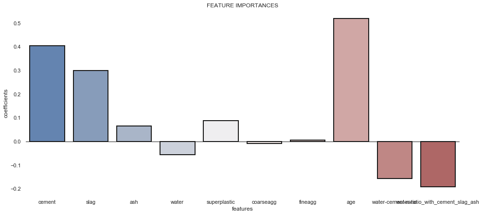

```python
coef = pd.DataFrame(model.coef_.ravel())
coef["feat"] = x_train.columns
plt.figure(figsize=(16,7))
ax1 = sns.barplot(coef["feat"],coef[0], palette = "vlag", linewidth = 2, edgecolor = "k"*coef["feat"].nunique())
ax1.set_facecolor("white")
ax1.axhline(0, color = "k", linewidth=1)
plt.ylabel("coefficients")
plt.xlabel("features")
plt.title('FEATURE IMPORTANCES');
```

Observation : Features of High Importance.

1. "Age"
2. "Cement"
3. "Slag"
4. "Slag, Ash, Water & Cement Ratio"
5. "Water Ratio with Cement"

```python
# Building table to compare various models scores

log_cols = ["Classifier", "Mean Absolute Error","Mean Squared Error","R2 Score"]
log = pd.DataFrame(columns=log_cols)

log_entry = pd.DataFrame([["Support Vector Regressor",SVR_MAE,SVR_MSE,SVR_R2]], columns=log_cols)
log = log.append(log_entry)
log
```

|  | Classifier | Mean Absolute Error | Mean Squared Error | R2 Score |
| --- | --- | --- | --- | --- |
| 0 | Support Vector Regressor | 0.262186 | 0.143665 | 0.862766 |

### Creating Polynomial Features

```python
poly = PolynomialFeatures(degree = 2, interaction_only = True)
```

```python
x_train1 = poly.fit_transform(x_train)
x_val1 = poly.fit_transform(x_val)
x_test1 = poly.fit_transform(x_test)
```

### B. Ridge Linear Regression

```python
pipe_ridge = Pipeline([('scl', StandardScaler()), ('Ridge', Ridge())])     # Pipeline building
param_grid = {'Ridge__alpha': [0.1, 1,0.01]}      # Parameter grid
grid_ridge = GridSearchCV( pipe_ridge , param_grid = param_grid, cv = 5)


grid_ridge.fit(x_train1, y_train)      # Fitting the data in the model

print(" Best Cross-Validation Score obtained is: {:.2f}". format( grid_ridge.best_score_))
print(" Best Parameters as part of Gridsearch is: ", grid_ridge.best_params_)
print(" Training Set Score obtained is: {:.2f}". format( grid_ridge.score(x_train1, y_train)))
print(" Validation Set Score obtained is: {:.2f}". format( grid_ridge.score(x_val1, y_val)))
print(" Testing Set Score obtained is: {:.2f}". format( grid_ridge.score(x_test1, y_test)))
```

```
 Best Cross-Validation Score obtained is: 0.73
 Best Parameters as part of Gridsearch is:  {'Ridge__alpha': 1}
 Training Set Score obtained is: 0.79
 Validation Set Score obtained is: 0.66
 Testing Set Score obtained is: 0.75
```

```python
ypre = grid_ridge.predict(x_test1)
```

```python
# Evaluating the performance

Ridge_MAE = metrics.mean_absolute_error(y_test, ypre)
Ridge_MSE = metrics.mean_squared_error(y_test, ypre)
Ridge_R2 = metrics.r2_score(y_test, ypre)
print("The Mean Absolute Error is : {:.2f}".format(Ridge_MAE))
print("The Mean Squared Error is : {:.2f}".format(Ridge_MSE))
print("The R2 score is : {:.2f}".format(Ridge_R2))
```

```
The Mean Absolute Error is : 0.39
The Mean Squared Error is : 0.26
The R2 score is : 0.75
```

```python
log_entry = pd.DataFrame([["Ridge Regressor",Ridge_MAE,Ridge_MSE,Ridge_R2]], columns=log_cols)
log = log.append(log_entry)
log
```

|  | Classifier | Mean Absolute Error | Mean Squared Error | R2 Score |
| --- | --- | --- | --- | --- |
| 0 | Support Vector Regressor | 0.262186 | 0.143665 | 0.862766 |
| 0 | Ridge Regressor | 0.392384 | 0.257963 | 0.753585 |

### C. Lasso Linear Regression

```python
pipe_lasso = Pipeline([('scl', StandardScaler()), ('Lasso', Lasso())])     # Pipeline building
param_grid = {'Lasso__alpha': [0.1, 1,0.01]}      # Parameter grid
random_lasso = RandomizedSearchCV( pipe_lasso , param_distributions=param_grid, cv = 5, n_iter=3)     # Using RandomSearchCV

random_lasso.fit(x_train1, y_train)       #Fitting the data in the model

print(" Best Cross-Validation Score obtained is: {:.2f}". format(random_lasso.best_score_))
print(" Best Parameters as part of Randomsearch is: ", random_lasso.best_params_)
print(" Training Set Score btained is: {:.2f}". format(random_lasso.score(x_train1, y_train)))
print(" Validation Set Score obtained is: {:.2f}". format(random_lasso.score(x_val1, y_val)))
print(" Testing Set Score obtained is: {:.2f}". format(random_lasso.score(x_test1, y_test)))
```

```
 Best Cross-Validation Score obtained is: 0.74
 Best Parameters as part of Randomsearch is:  {'Lasso__alpha': 0.01}
 Training Set Score btained is: 0.77
 Validation Set Score obtained is: 0.66
 Testing Set Score obtained is: 0.73
```

```python
ypr = random_lasso.predict(x_test1)
```

```python
# Evaluating the performance

Lasso_MAE = metrics.mean_absolute_error(y_test, ypr)
Lasso_MSE = metrics.mean_squared_error(y_test,ypr)
Lasso_R2 = metrics.r2_score(y_test,ypr)
print("The mean_absolute_error is : {:.2f}".format(Lasso_MAE))
print("The mean_squared_error is : {:.2f}".format(Lasso_MSE))
print("The R2 score is : {:.2f}".format(Lasso_R2))
```

```
The mean_absolute_error is : 0.40
The mean_squared_error is : 0.28
The R2 score is : 0.73
```

```python
# Building table to compare various models scores

log_entry = pd.DataFrame([["Lasso Regressor",Lasso_MAE,Lasso_MSE,Lasso_R2]], columns=log_cols)
log = log.append(log_entry)
log
```

|  | Classifier | Mean Absolute Error | Mean Squared Error | R2 Score |
| --- | --- | --- | --- | --- |
| 0 | Support Vector Regressor | 0.262186 | 0.143665 | 0.862766 |
| 0 | Ridge Regressor | 0.392384 | 0.257963 | 0.753585 |
| 0 | Lasso Regressor | 0.403684 | 0.283667 | 0.729032 |

### D. Decision Tree Regression

```python
pipe_DTR = Pipeline([('scl', StandardScaler()), ('DTR', DecisionTreeRegressor(max_depth = 10))])      #Pipeline with pruning the data for regularization to avoid overfit
param_grid = {'DTR__criterion': ["mse", "mae"],'DTR__min_samples_split':[2,4,6,8],'DTR__min_samples_leaf':[2,3,4,5]}     # Parameter grid
random_DTR = RandomizedSearchCV(pipe_DTR , param_distributions = param_grid, cv = 5, n_iter=5)      # Using RandomSearchCV

random_DTR.fit(x_train, y_train)       #Fitting the data in the model

print(" Best Cross-Validation Score obtained is: {:.2f}". format(random_DTR.best_score_))
print(" Best Parameters as part of Randomsearch is: ", random_DTR.best_params_)
print(" Training Set Score obtained is: {:.2f}". format(random_DTR.score(x_train, y_train)))
print(" Validation Set Score obtained is: {:.2f}". format(random_DTR.score(x_val, y_val)))
print(" Testing Set Score obtained is: {:.2f}". format(random_DTR.score(x_test, y_test)))
```

```
 Best Cross-Validation Score obtained is: 0.80
 Best Parameters as part of Randomsearch is:  {'DTR__min_samples_split': 6, 'DTR__min_samples_leaf': 2, 'DTR__criterion': 'mse'}
 Training Set Score obtained is: 0.96
 Validation Set Score obtained is: 0.79
 Testing Set Score obtained is: 0.81
```

```python
yp = random_DTR.predict(x_test)
```

```python
DTR_MAE = metrics.mean_absolute_error(y_test,yp)
DTR_MSE = metrics.mean_squared_error(y_test,yp)
DTR_R2 = metrics.r2_score(y_test,yp)
print("The Mean Absolute Error is : {:.2f}".format(DTR_MAE))
print("The Mean Squared Error is : {:.2f}".format(DTR_MSE))
print("The R2 score is : {:.2f}".format(DTR_R2))
```

```
The Mean Absolute Error is : 0.30
The Mean Squared Error is : 0.20
The R2 score is : 0.81
```

```python
model0 = DecisionTreeRegressor(min_samples_split= 4, min_samples_leaf = 2, criterion = 'mse', max_depth = 10)
```

```python
model0.fit(x_train, y_train)      # Fitting the model
```

```
DecisionTreeRegressor(max_depth=10, min_samples_leaf=2, min_samples_split=4)
```

```python
model0.feature_importances_
```

```
array([0.06672788, 0.02327645, 0.02058255, 0.01971124, 0.00685374,
       0.01009664, 0.02262281, 0.33325526, 0.08922812, 0.40764532])
```

```python
# Calculating feature of high importance

feat_imp_dict = dict(zip(x.columns, model0.feature_importances_))
feat_imp = pd.DataFrame.from_dict(feat_imp_dict, orient='index')
feat_imp.sort_values(by = 0, ascending = False)
```

|  | 0 |
| --- | --- |
| water-ratio_with_cement_slag_ash | 0.407645 |
| age | 0.333255 |
| water-cement-ratio | 0.089228 |
| cement | 0.066728 |
| slag | 0.023276 |
| fineagg | 0.022623 |
| ash | 0.020583 |
| water | 0.019711 |
| coarseagg | 0.010097 |
| superplastic | 0.006854 |

```python
log_entry = pd.DataFrame([["Decision Tree Regressor",DTR_MAE,DTR_MSE,DTR_R2]], columns=log_cols)
log = log.append(log_entry)
log
```

|  | Classifier | Mean Absolute Error | Mean Squared Error | R2 Score |
| --- | --- | --- | --- | --- |
| 0 | Support Vector Regressor | 0.262186 | 0.143665 | 0.862766 |
| 0 | Ridge Regressor | 0.392384 | 0.257963 | 0.753585 |
| 0 | Lasso Regressor | 0.403684 | 0.283667 | 0.729032 |
| 0 | Decision Tree Regressor | 0.303614 | 0.202507 | 0.806558 |

### E. Gradient Boosting Regressor

```python
pipe_GBR = Pipeline([('scl', StandardScaler()), ('GBR', GradientBoostingRegressor())])     # Pipeline building
param_grid = {'GBR__n_estimators': [50,100,150,200],'GBR__learning_rate':[0.1,1,0.5,1.5]}      # Parameter grid
random_GBR = RandomizedSearchCV(pipe_GBR , param_distributions = param_grid, cv = 5, n_iter=3)       # Using RandomSearchCV


random_GBR.fit(x_train, y_train.values.ravel())       # Fitting the data in the model

print(" Best cross-validation score obtained is: {:.2f}". format(random_GBR.best_score_))
print(" Best parameters as part of Randomsearch is: ", random_GBR.best_params_)
print(" Training Set Score obtained is: {:.2f}". format(random_GBR.score(x_train, y_train)))
print(" Validation Set Score obtained is: {:.2f}". format(random_GBR.score(x_val, y_val)))
print(" Testing Set Score obtained is: {:.2f}". format(random_GBR.score(x_test, y_test)))
```

```
 Best cross-validation score obtained is: 0.89
 Best parameters as part of Randomsearch is:  {'GBR__n_estimators': 200, 'GBR__learning_rate': 0.1}
 Training Set Score obtained is: 0.97
 Validation Set Score obtained is: 0.90
 Testing Set Score obtained is: 0.89
```

```python
ypd = random_GBR.predict(x_test)
```

```python
GBR_MAE = metrics.mean_absolute_error(y_test, ypd)
GBR_MSE = metrics.mean_squared_error(y_test, ypd)
GBR_R2 = metrics.r2_score(y_test, ypd)
print("The Mean Absolute Error is : {:.2f}".format(GBR_MAE))
print("The Mean Squared Error is : {:.2f}".format(GBR_MSE))
print("The R2 score is : {:.2f}".format(GBR_R2))
```

```
The Mean Absolute Error is : 0.22
The Mean Squared Error is : 0.12
The R2 score is : 0.89
```

```python
model1 = GradientBoostingRegressor(n_estimators = 200, learning_rate = 0.1)
```

```python
model1.fit(x_train, y_train.values.ravel())
```

```
GradientBoostingRegressor(n_estimators=200)
```

```python
model1.feature_importances_
```

```
array([0.04541746, 0.02071206, 0.02194389, 0.03974341, 0.01183395,
       0.00977859, 0.01368114, 0.3674506 , 0.11268508, 0.35675381])
```

```python
# Calculating feature of high importance

feat_imp_dict = dict(zip(x.columns, model1.feature_importances_))
feat_imp = pd.DataFrame.from_dict(feat_imp_dict, orient = 'index')
feat_imp.sort_values(by = 0, ascending = False)
```

|  | 0 |
| --- | --- |
| age | 0.367451 |
| water-ratio_with_cement_slag_ash | 0.356754 |
| water-cement-ratio | 0.112685 |
| cement | 0.045417 |
| water | 0.039743 |
| ash | 0.021944 |
| slag | 0.020712 |
| fineagg | 0.013681 |
| superplastic | 0.011834 |
| coarseagg | 0.009779 |

```python
# Building table to compare various models scores

log_entry = pd.DataFrame([["Gradient Boosting Regressor",GBR_MAE,GBR_MSE,GBR_R2]], columns=log_cols)
log = log.append(log_entry)
log
```

|  | Classifier | Mean Absolute Error | Mean Squared Error | R2 Score |
| --- | --- | --- | --- | --- |
| 0 | Support Vector Regressor | 0.262186 | 0.143665 | 0.862766 |
| 0 | Ridge Regressor | 0.392384 | 0.257963 | 0.753585 |
| 0 | Lasso Regressor | 0.403684 | 0.283667 | 0.729032 |
| 0 | Decision Tree Regressor | 0.303614 | 0.202507 | 0.806558 |
| 0 | Gradient Boosting Regressor | 0.216725 | 0.118881 | 0.886440 |

### F. Random Forest Regressor

```python
pipe_RFR = Pipeline([('scl', StandardScaler()), ('RFR', RandomForestRegressor(max_depth = 25))])     # Pipeline building
param_grid = {'RFR__n_estimators': [50,150,100,250],'RFR__criterion':['mse','mae'], 'RFR__min_samples_split':[2,4,6,8],'RFR__min_samples_leaf':[2,3,4,5]}      # Parameter grid
random_RFR = RandomizedSearchCV(pipe_RFR , param_distributions = param_grid, cv = 5, n_iter=3)       # Using RandomSearchCV


random_RFR.fit(x_train, y_train.values.ravel())       # Fitting the data in the model

print(" Best cross-validation score obtained is: {:.2f}". format(random_RFR.best_score_))

print(" Best parameters as part of Randomsearch is: ", random_RFR.best_params_)
print(" Training Set Score obtained is: {:.2f}". format(random_RFR.score(x_train, y_train)))
print(" Validation Set Score obtained is: {:.2f}". format(random_RFR.score(x_val, y_val)))
print(" Testing Set Score obtained is: {:.2f}". format(random_RFR.score(x_test, y_test)))
```

```
 Best cross-validation score obtained is: 0.88
 Best parameters as part of Randomsearch is:  {'RFR__n_estimators': 150, 'RFR__min_samples_split': 4, 'RFR__min_samples_leaf': 2, 'RFR__criterion': 'mse'}
 Training Set Score obtained is: 0.97
 Validation Set Score obtained is: 0.88
 Testing Set Score obtained is: 0.89
```

```python
y_pd = random_RFR.predict(x_test)
```

```python
RFR_MAE = metrics.mean_absolute_error(y_test, y_pd)
RFR_MSE = metrics.mean_squared_error(y_test, y_pd)
RFR_R2 = metrics.r2_score(y_test, y_pd)
print("The Mean Absolute Error is : {:.2f}".format(RFR_MAE))
print("The Mean Squared Error is : {:.2f}".format(RFR_MSE))
print("The R2 score is : {:.2f}".format(RFR_R2))
```

```
The Mean Absolute Error is : 0.22
The Mean Squared Error is : 0.11
The R2 score is : 0.89
```

```python
model2 = RandomForestRegressor(n_estimators = 150, criterion = 'mse', min_samples_split = 4, min_samples_leaf = 2)
```

```python
model2.fit(x_train, y_train.values.ravel())
```

```
RandomForestRegressor(min_samples_leaf=2, min_samples_split=4, n_estimators=150)
```

```python
model2.feature_importances_
```

```
array([0.06323033, 0.02715245, 0.01967529, 0.0215652 , 0.01402871,
       0.01442084, 0.02218677, 0.33640723, 0.06020842, 0.42112476])
```

```python
## Calculating feature importance

feat_imp_dict = dict(zip(x.columns, model2.feature_importances_))
feat_imp = pd.DataFrame.from_dict(feat_imp_dict, orient = 'index')
feat_imp.sort_values(by = 0, ascending = False)
```

|  | 0 |
| --- | --- |
| water-ratio_with_cement_slag_ash | 0.421125 |
| age | 0.336407 |
| cement | 0.063230 |
| water-cement-ratio | 0.060208 |
| slag | 0.027152 |
| fineagg | 0.022187 |
| water | 0.021565 |
| ash | 0.019675 |
| coarseagg | 0.014421 |
| superplastic | 0.014029 |

```python
# Building table to compare various models scores

log_entry = pd.DataFrame([["Random Forest Regressor",RFR_MAE,RFR_MSE,RFR_R2]], columns=log_cols)
log = log.append(log_entry)
log
```

|  | Classifier | Mean Absolute Error | Mean Squared Error | R2 Score |
| --- | --- | --- | --- | --- |
| 0 | Support Vector Regressor | 0.262186 | 0.143665 | 0.862766 |
| 0 | Ridge Regressor | 0.392384 | 0.257963 | 0.753585 |
| 0 | Lasso Regressor | 0.403684 | 0.283667 | 0.729032 |
| 0 | Decision Tree Regressor | 0.303614 | 0.202507 | 0.806558 |
| 0 | Gradient Boosting Regressor | 0.216725 | 0.118881 | 0.886440 |
| 0 | Random Forest Regressor | 0.222350 | 0.114235 | 0.890879 |

### G. KNeighbors Regressor

```python
pipe_KNN = Pipeline([('scl', StandardScaler()), ('KNN', KNeighborsRegressor(n_neighbors = 9))])     # Pipeline building
param_grid = {'KNN__algorithm': ['ball_tree', 'kd_tree', 'brute'], 'KNN__weights':['uniform','distance']}      # Parameter grid
grid_KNN = GridSearchCV(pipe_KNN , param_grid = param_grid, cv = 5)       # Using RandomSearchCV


grid_KNN.fit(x_train, y_train.values.ravel())       # Fitting the data in the model

print(" Best cross-validation score obtained is: {:.2f}". format(grid_KNN.best_score_))
print(" Best parameters as part of Randomsearch is: ", grid_KNN.best_params_)
print(" Training Set Score obtained is: {:.2f}". format(grid_KNN.score(x_train, y_train)))
print(" Validation Set Score obtained is: {:.2f}". format(grid_KNN.score(x_val, y_val)))
print(" Testing Set Score obtained is: {:.2f}". format(grid_KNN.score(x_test, y_test)))
```

```
 Best cross-validation score obtained is: 0.77
 Best parameters as part of Randomsearch is:  {'KNN__algorithm': 'kd_tree', 'KNN__weights': 'distance'}
 Training Set Score obtained is: 0.99
 Validation Set Score obtained is: 0.74
 Testing Set Score obtained is: 0.82
```

```python
y_prd = grid_KNN.predict(x_test)
```

```python
KNN_MAE = metrics.mean_absolute_error(y_test, y_prd)
KNN_MSE = metrics.mean_squared_error(y_test, y_prd)
KNN_R2 = metrics.r2_score(y_test, y_prd)
print("The Mean Absolute Error is : {:.2f}".format(KNN_MAE))
print("The Mean Squared Error is : {:.2f}".format(KNN_MSE))
print("The R2 score is : {:.2f}".format(KNN_R2))
```

```
The Mean Absolute Error is : 0.30
The Mean Squared Error is : 0.19
The R2 score is : 0.82
```

```python
# Building table to compare various models scores

log_entry = pd.DataFrame([["KNeighbors Regressor",KNN_MAE,KNN_MSE,KNN_R2]], columns=log_cols)
log = log.append(log_entry)
log
```

|  | Classifier | Mean Absolute Error | Mean Squared Error | R2 Score |
| --- | --- | --- | --- | --- |
| 0 | Support Vector Regressor | 0.262186 | 0.143665 | 0.862766 |
| 0 | Ridge Regressor | 0.392384 | 0.257963 | 0.753585 |
| 0 | Lasso Regressor | 0.403684 | 0.283667 | 0.729032 |
| 0 | Decision Tree Regressor | 0.303614 | 0.202507 | 0.806558 |
| 0 | Gradient Boosting Regressor | 0.216725 | 0.118881 | 0.886440 |
| 0 | Random Forest Regressor | 0.222350 | 0.114235 | 0.890879 |
| 0 | KNeighbors Regressor | 0.297293 | 0.193231 | 0.815419 |

### Creating a pair plot for the feature Engineered data-set to infer the occurance of multiple guasians

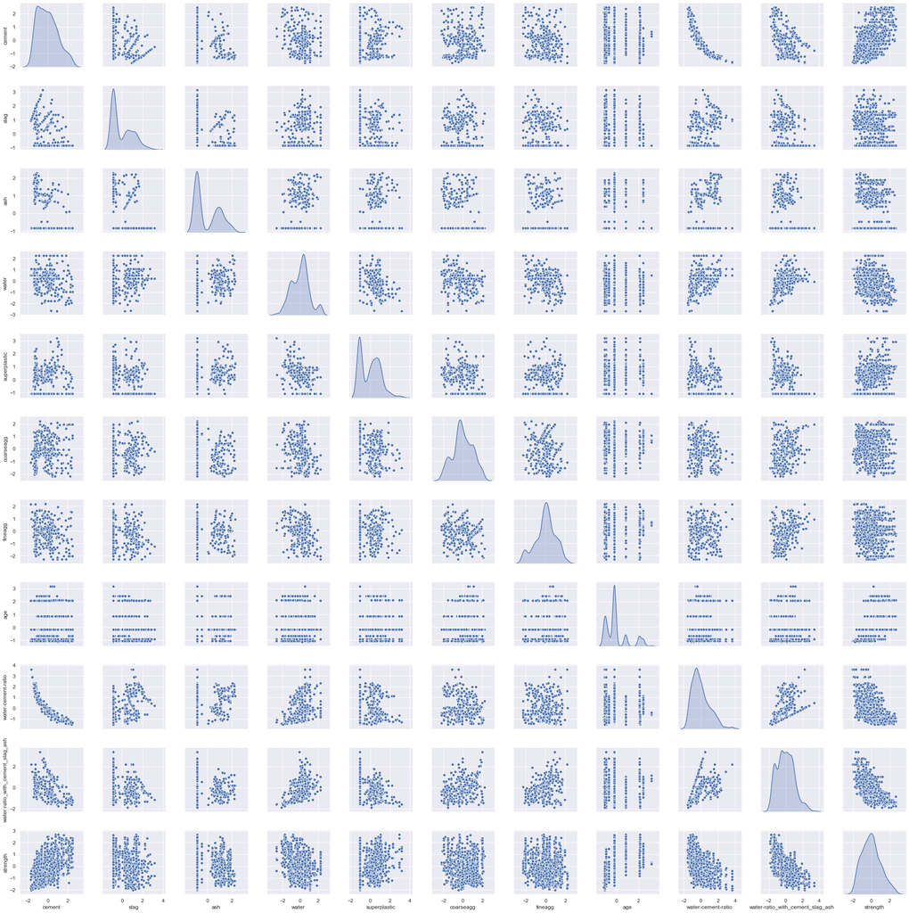

```python
sns.pairplot(df_new, palette = "Set2", diag_kind = "kde", height = 2.5)
```

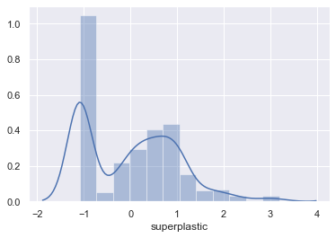

```python
sns.distplot(df_new['superplastic'])
```

### Splitting the data-set based on the 2 guassians

```python
data_guassian1 = df_new[df_new['superplastic']>=0]
```

```python
data_guassian1.head()
```

|  | cement | slag | ash | water | superplastic | coarseagg | fineagg | age | water-cement-ratio | water-ratio_with_cement_slag_ash | strength |
| --- | --- | --- | --- | --- | --- | --- | --- | --- | --- | --- | --- |
| 1 | -1.074790 | -0.363717 | 1.096078 | -1.134020 | 0.881615 | 1.388141 | 0.300692 | -0.656933 | 0.602220 | 0.013241 | -0.736906 |
| 4 | -1.209776 | 1.290784 | -0.847144 | 0.565570 | 0.571085 | 0.958372 | -0.964165 | -0.153159 | 1.597951 | 0.799068 | -1.054112 |
| 7 | -0.284981 | -0.858192 | 1.002278 | 0.332483 | 0.077890 | 0.713893 | -0.188725 | 0.854391 | 0.002993 | 0.312314 | 0.060972 |
| 9 | -1.207861 | 1.297814 | 1.388421 | 0.599562 | 0.552818 | -1.195619 | -0.934927 | -0.153159 | 1.607237 | -0.535079 | -0.403900 |
| 10 | -1.238496 | 1.228682 | 1.321198 | -0.687271 | 2.251602 | -0.372109 | -0.990860 | -0.153159 | 1.133497 | -0.890518 | 0.043349 |

```python
data_guassian2 = df_new[df_new['superplastic']<0]
```

```python
data_guassian1.head()
```

|  | cement | slag | ash | water | superplastic | coarseagg | fineagg | age | water-cement-ratio | water-ratio_with_cement_slag_ash | strength |
| --- | --- | --- | --- | --- | --- | --- | --- | --- | --- | --- | --- |
| 1 | -1.074790 | -0.363717 | 1.096078 | -1.134020 | 0.881615 | 1.388141 | 0.300692 | -0.656933 | 0.602220 | 0.013241 | -0.736906 |
| 4 | -1.209776 | 1.290784 | -0.847144 | 0.565570 | 0.571085 | 0.958372 | -0.964165 | -0.153159 | 1.597951 | 0.799068 | -1.054112 |
| 7 | -0.284981 | -0.858192 | 1.002278 | 0.332483 | 0.077890 | 0.713893 | -0.188725 | 0.854391 | 0.002993 | 0.312314 | 0.060972 |
| 9 | -1.207861 | 1.297814 | 1.388421 | 0.599562 | 0.552818 | -1.195619 | -0.934927 | -0.153159 | 1.607237 | -0.535079 | -0.403900 |
| 10 | -1.238496 | 1.228682 | 1.321198 | -0.687271 | 2.251602 | -0.372109 | -0.990860 | -0.153159 | 1.133497 | -0.890518 | 0.043349 |

### Splitting the data set into test and train

```python
X1 = data_guassian1.drop(['strength'],axis=1)
Y1 = data_guassian1['strength']
```

```python
X2=data_guassian2.drop(['strength'],axis=1)
Y2=data_guassian2['strength']
```

```python
X1train, X1test, Y1train, Y1test = train_test_split(X1, Y1, test_size=0.3, random_state=1)
```

```python
X2train, X2test, Y2train, Y2test = train_test_split(X2, Y2, test_size=0.3,random_state=1)
```

```python
model1= GradientBoostingRegressor(n_estimators=200,learning_rate=0.1)
```

```python
model1.fit(X1train, Y1train)
```

```
GradientBoostingRegressor(n_estimators=200)
```

```python
print("Guassian 1 Train score is :{:.2f}".format(model1.score(X1train, Y1train)))
```

```
Guassian 1 Train score is :0.98
```

```python
print("Guassian 1 Test score is :{:.2f}".format(model1.score(X1test, Y1test)))
```

```
Guassian 1 Test score is :0.85
```

```python
model1.fit(X2train, Y2train)
```

```
GradientBoostingRegressor(n_estimators=200)
```

```python
print("Guassian 2 Train score is :{:.2f}".format(model1.score(X2train, Y2train)))
```

```
Guassian 2 Train score is :0.98
```

```python
print("Guassian 2 Test score is :{:.2f}".format(model1.score(X2test, Y2test)))
```

```
Guassian 2 Test score is :0.90
```

Comparing the train and test scores of both the guassians, they perform almost alike. Hence splitting and creating multiple models is not very fruitful

### Bootstrapping Confidence Level

```python
# configure bootstrap
values = df_new.values



n_iterations = 1000              # Number of bootstrap samples to create
n_size = int(len(df_new) * 1)    # size of a bootstrap sample

# run bootstrap
stats = list()   # empty list that will hold the scores for each bootstrap iteration

for i in range(n_iterations):

    # prepare train and test sets
    train = resample(values, n_samples = n_size)  # Sampling with replacement
    test = np.array([x for x in values if x.tolist() not in train.tolist()])  # picking rest of the data not considered in sample

    # fit model
    pipe_RFR = RandomForestRegressor(n_estimators = 150)
    pipe_RFR.fit(train[:,:-1], train[:,-1])   # fit against independent variables and corresponding target values

    pipe_RFR.fit(train[:,:-1], train[:,-1])   # fit against independent variables and corresponding target values
    y_test = test[:,-1]    # Take the target column for all rows in test set

    # evaluate model
    predictions = pipe_RFR.predict(test[:, :-1])   # predict based on independent variables in the test data
    score = pipe_RFR.score(test[:, :-1] , y_test)

    stats.append(score)
```

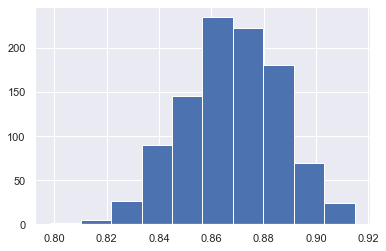

```
95.0 confidence interval 83.1% and 90.2%
```

```python
# plot scores
pyplot.hist(stats)
pyplot.show()
# confidence intervals
alpha = 0.95                             # for 95% confidence
p = ((1.0 - alpha)/2.0) * 100              # tail regions on right and left .25 on each side indicated by P value (border)
lower = max(0.0, np.percentile(stats, p))
p = (alpha+((1.0-alpha)/2.0)) * 100
upper = min(1.0, np.percentile(stats, p))
print('%.1f confidence interval %.1f%% and %.1f%%' % (alpha*100, lower*100, upper*100))
```